# Analise Vinhos Tintos

# Análise de Vinhos Tinto

======================================================== > por Ricardo Lino > Descrição do Conjunto de Dados escolhido: Este conjunto de dados contém 1.599 vinhos tintos com 11 variáveis de propriedades químicas do vinho. Ao menos 3 especialistas em vinhos avaliaram cada vinho, fornecendo uma nota entre 0 (muito ruim) e 10 (muito excelente).

Questão Guia: Quais propriedades químicas influenciam a qualidade dos vinhos tintos?

origem: “https://s3.amazonaws.com/udacity-hosted-downloads/ud651/wineQualityInfo.txt”

Author: P. Cortez, A. Cerdeira, F. Almeida, T. Matos and J. Reis. Modeling wine preferences by data mining from physicochemical properties. In Decision Support Systems, Elsevier, 47(4):547-553. ISSN: 0167-9236.

```
## [1] "Dimensão dos dados:  1599" "Dimensão dos dados:  13"
```

```
## 'data.frame':    1599 obs. of  13 variables:
##  $ X                   : int  1 2 3 4 5 6 7 8 9 10 ...
##  $ fixed.acidity       : num  7.4 7.8 7.8 11.2 7.4 7.4 7.9 7.3 7.8 7.5 ...
##  $ volatile.acidity    : num  0.7 0.88 0.76 0.28 0.7 0.66 0.6 0.65 0.58 0.5 ...
##  $ citric.acid         : num  0 0 0.04 0.56 0 0 0.06 0 0.02 0.36 ...
##  $ residual.sugar      : num  1.9 2.6 2.3 1.9 1.9 1.8 1.6 1.2 2 6.1 ...
##  $ chlorides           : num  0.076 0.098 0.092 0.075 0.076 0.075 0.069 0.065 0.073 0.071 ...
##  $ free.sulfur.dioxide : num  11 25 15 17 11 13 15 15 9 17 ...
##  $ total.sulfur.dioxide: num  34 67 54 60 34 40 59 21 18 102 ...
##  $ density             : num  0.998 0.997 0.997 0.998 0.998 ...
##  $ pH                  : num  3.51 3.2 3.26 3.16 3.51 3.51 3.3 3.39 3.36 3.35 ...
##  $ sulphates           : num  0.56 0.68 0.65 0.58 0.56 0.56 0.46 0.47 0.57 0.8 ...
##  $ alcohol             : num  9.4 9.8 9.8 9.8 9.4 9.4 9.4 10 9.5 10.5 ...
##  $ quality             : int  5 5 5 6 5 5 5 7 7 5 ...
## [1] "Estrutura dos Dados:  "
```

```
##        X          fixed.acidity   volatile.acidity  citric.acid
##  Min.   :   1.0   Min.   : 4.60   Min.   :0.1200   Min.   :0.000
##  1st Qu.: 400.5   1st Qu.: 7.10   1st Qu.:0.3900   1st Qu.:0.090
##  Median : 800.0   Median : 7.90   Median :0.5200   Median :0.260
##  Mean   : 800.0   Mean   : 8.32   Mean   :0.5278   Mean   :0.271
##  3rd Qu.:1199.5   3rd Qu.: 9.20   3rd Qu.:0.6400   3rd Qu.:0.420
##  Max.   :1599.0   Max.   :15.90   Max.   :1.5800   Max.   :1.000
##  residual.sugar     chlorides       free.sulfur.dioxide
##  Min.   : 0.900   Min.   :0.01200   Min.   : 1.00
##  1st Qu.: 1.900   1st Qu.:0.07000   1st Qu.: 7.00
##  Median : 2.200   Median :0.07900   Median :14.00
##  Mean   : 2.539   Mean   :0.08747   Mean   :15.87
##  3rd Qu.: 2.600   3rd Qu.:0.09000   3rd Qu.:21.00
##  Max.   :15.500   Max.   :0.61100   Max.   :72.00
##  total.sulfur.dioxide    density             pH          sulphates
##  Min.   :  6.00       Min.   :0.9901   Min.   :2.740   Min.   :0.3300
##  1st Qu.: 22.00       1st Qu.:0.9956   1st Qu.:3.210   1st Qu.:0.5500
##  Median : 38.00       Median :0.9968   Median :3.310   Median :0.6200
##  Mean   : 46.47       Mean   :0.9967   Mean   :3.311   Mean   :0.6581
##  3rd Qu.: 62.00       3rd Qu.:0.9978   3rd Qu.:3.400   3rd Qu.:0.7300
##  Max.   :289.00       Max.   :1.0037   Max.   :4.010   Max.   :2.0000
##     alcohol         quality
##  Min.   : 8.40   Min.   :3.000
##  1st Qu.: 9.50   1st Qu.:5.000
##  Median :10.20   Median :6.000
##  Mean   :10.42   Mean   :5.636
##  3rd Qu.:11.10   3rd Qu.:6.000
##  Max.   :14.90   Max.   :8.000
```

## Informações dos Atributos

1 - fixed acidity (tartaric acid - g / dm^3) - acidos não volateis presentes no vinho.

2 - volatile acidity (acetic acid - g / dm^3) - a quantidade de acido acetico, que em grau elevado pode levar a um sabor não agradavel (gosto de vinagre).

3 - citric acid (g / dm^3) - encontrado em pequenas quantidade pode dar leveza e sabor ao vinhuo.

4 - residual sugar (g / dm^3) - o açucar encontrado no vinho após o final da fermentação. Raro encontrar vinhos com menos de 1 grama por litro. Vinhos com mais d 45 gramas por litro são considerados doces.

5 - chlorides (sodium chloride - g / dm^3)- a quantidade de sal no vinho.

6 - free sulfur dioxide (mg / dm^3) - dióxido de enxofre livre no vinho. Previne a oxidação do vinho a a proliferação de microorganismos.

7 - total sulfur dioxide (mg / dm^3)- total de dióxido de enxofre no vinho. Concentraçãoes acima de 50 ppm se tornam evidente ao cheirar e provar o vinho.

8 - density (g / cm^3) - densidade do vinho.

9 - pH - nivel de acidez do vinho, de 0 a muito ácido até 14 muito básico. A maioria dos vinhos esta numa faixa entre 3-4 na escala de ph.

10 - sulphates (potassium sulphate - g / dm3) - um aditivo ao vinho que contribui para preservar o vinho.

11 - alcohol - % de alcool no vinho

12 - quality (score between 0 and 10) - Variável se Saída - qualidade do vinho de 0 a 10.

## Seção de Gráficos Univariados

### Qualidade do Vinho

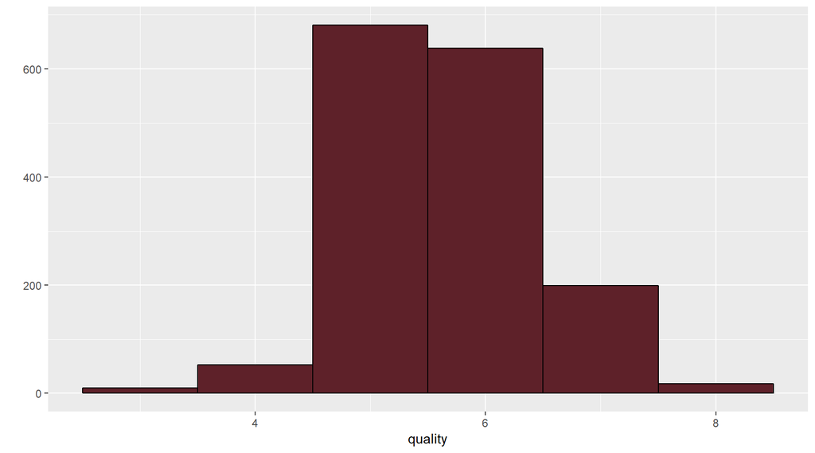

```
##
##   3   4   5   6   7   8
##  10  53 681 638 199  18
```

```
##    Min. 1st Qu.  Median    Mean 3rd Qu.    Max.
##   3.000   5.000   6.000   5.636   6.000   8.000
```

### SEÇÂO DE GRÀFICOS UNIVARIADOS

Primeiro vamos dar uma olhada geral na distribuição das variaveis do nosso data set. Assim podemos conhecer melhor o que temos e direcionar nossa analise

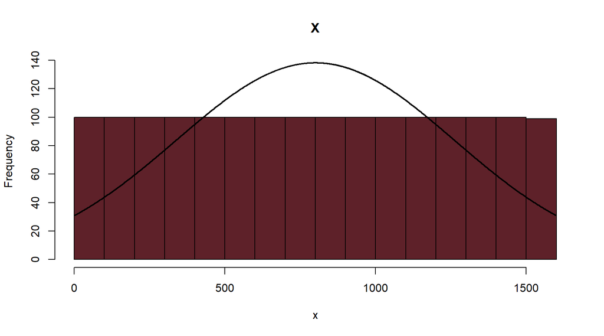

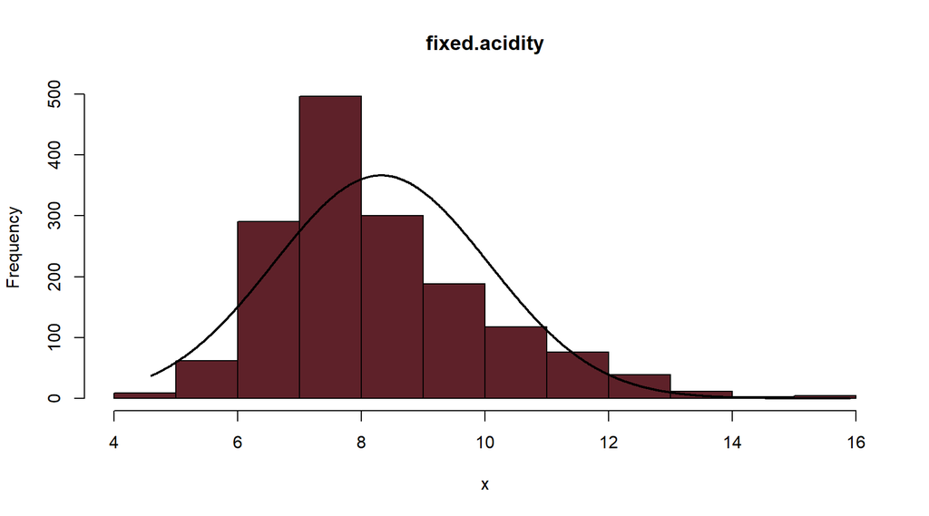

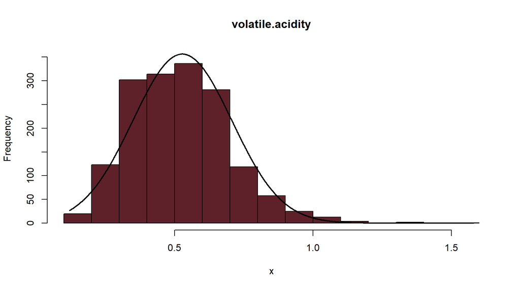

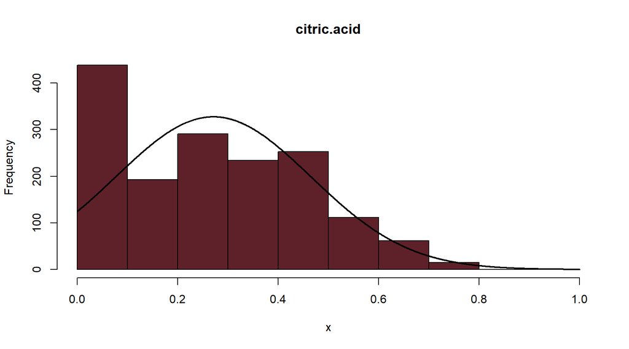

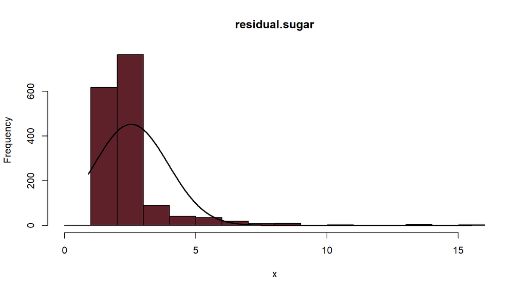

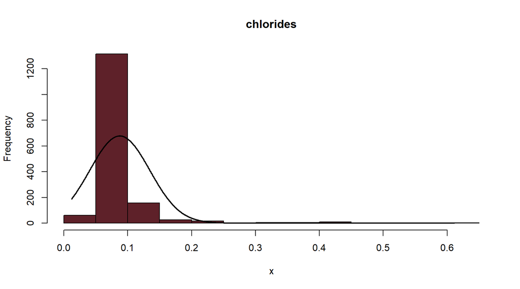

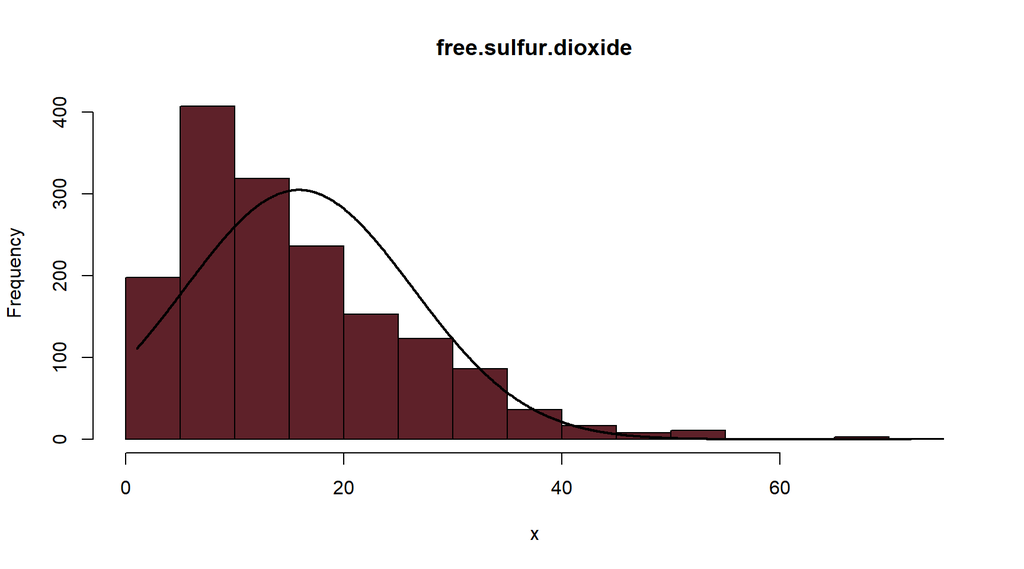

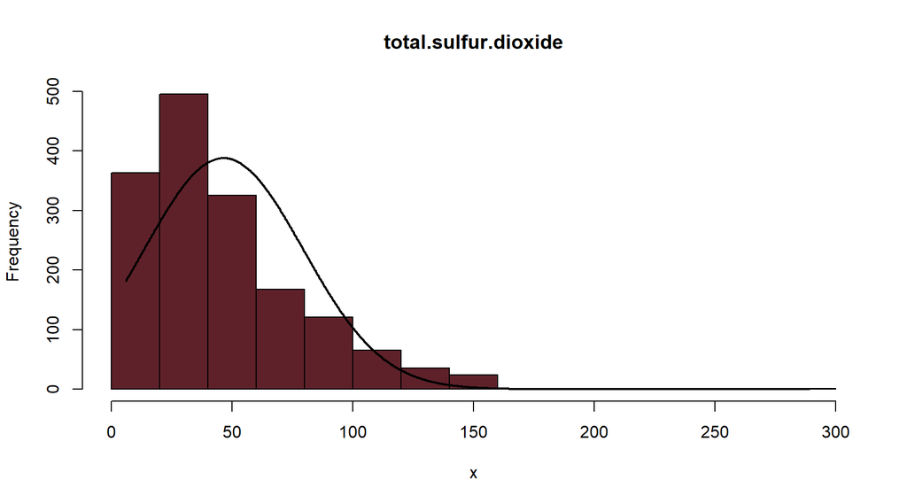

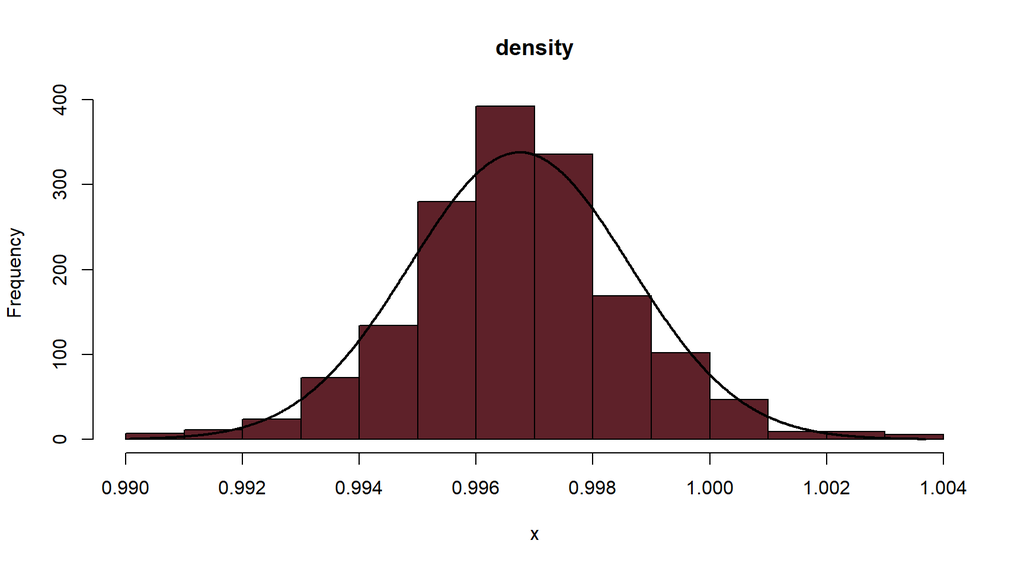

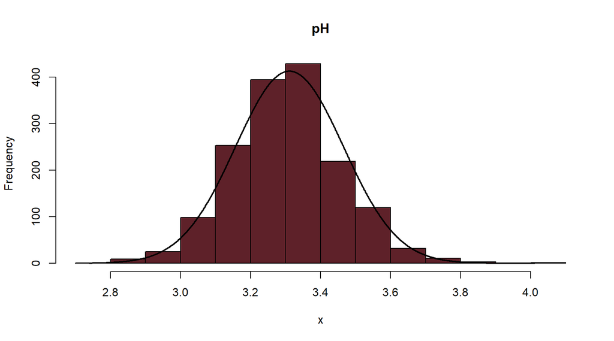

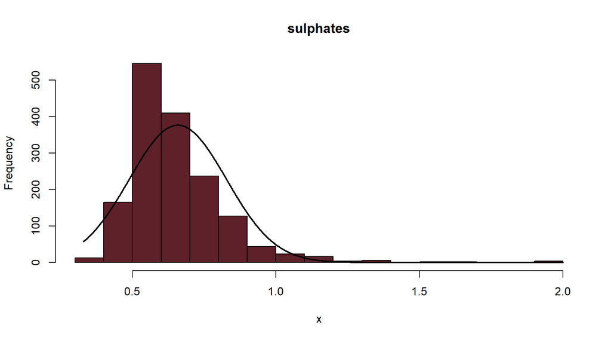

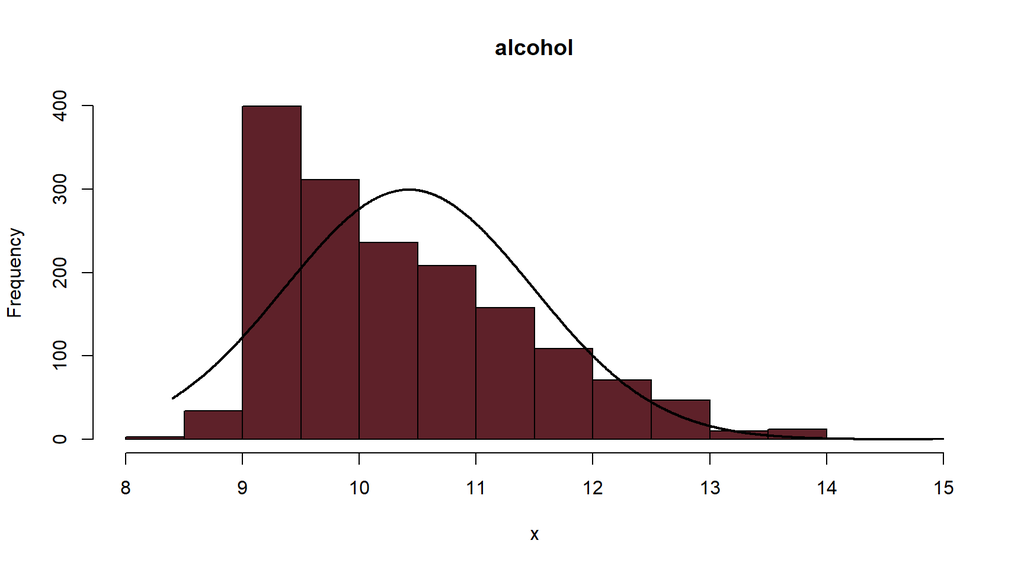

[1 more figures not shown]

### Tranformação de algumas variaveis

Eu elegi o nível de alcool, pH, sulfitos, acidez volatil e fixa e acido citrico. Transforma o nível de alcool, acidez volatil e fixa por uma Log. E o acido citrico pelo Tukey (tem valores zero)

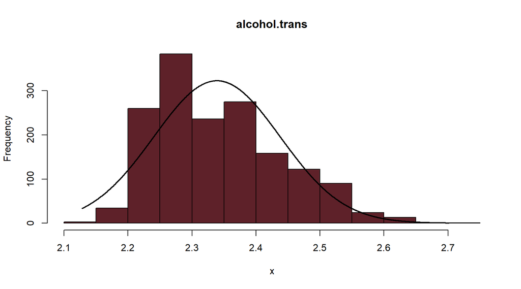

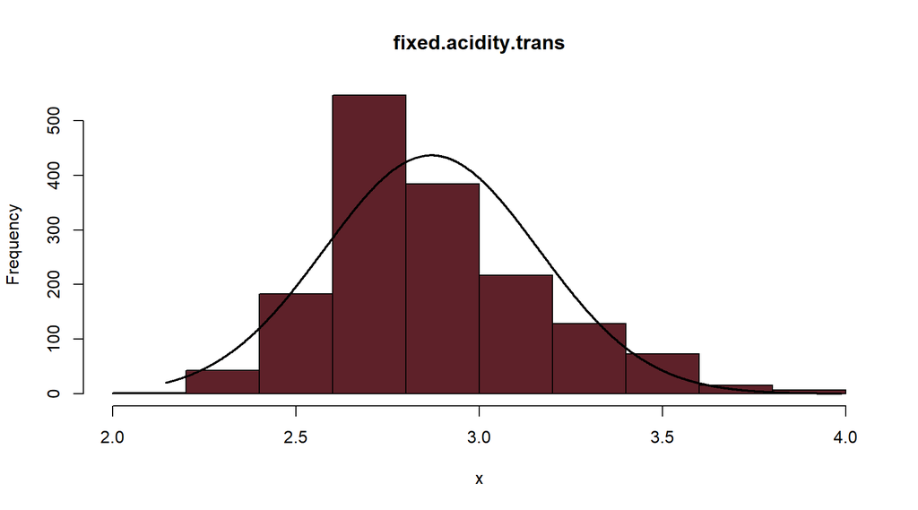

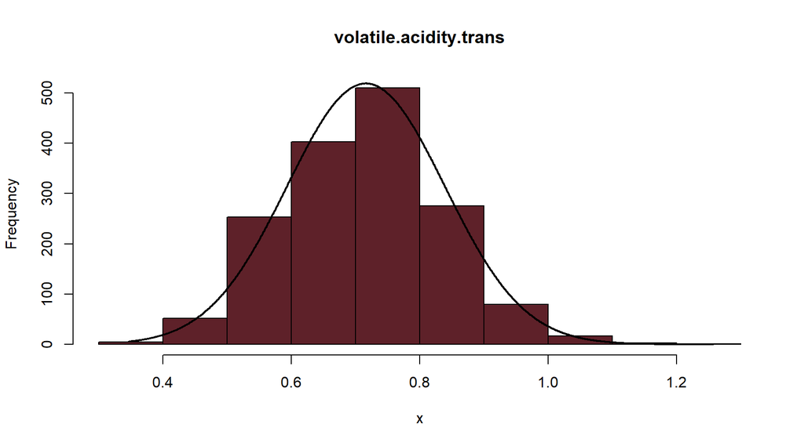

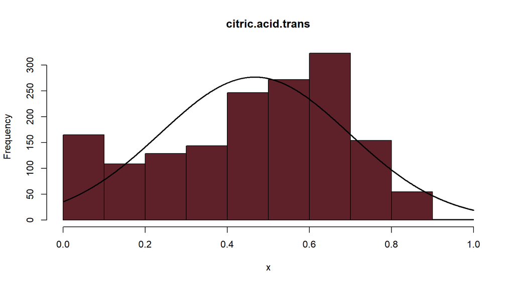

### Criação de uma nova variável categorica

Como me interessou ver o que influencia na classificacao de um vinho bom. Pensei em analisar o que diferencia um vinho bom da media, e tab o que diferencia um vinho ruim. Agrupei classificando os vinhos em LOW, AVG e TOP. Com base no summario de dados de qualidade, vamos pegar os vinho com menor qualidade do 1o quantil e maior classificação do que o 3o quantil e classifica-los.

```
##
##  LOW  AVG  TOP
##   63 1319  217
```

Sabemos que a classificação de um vinho leva em conta também o fator preço, que não temos no nosso dataset, por isso temos de tomar cuidado, as vezes um bom vinho em um preço não é um bom vinho a um nivel de preço mais alto. Mas mesmo assim vamos continuar nossa analise e escolher alguma variaveis para nosso estudo.

### 1- Acidos e acidez dos Vinhos

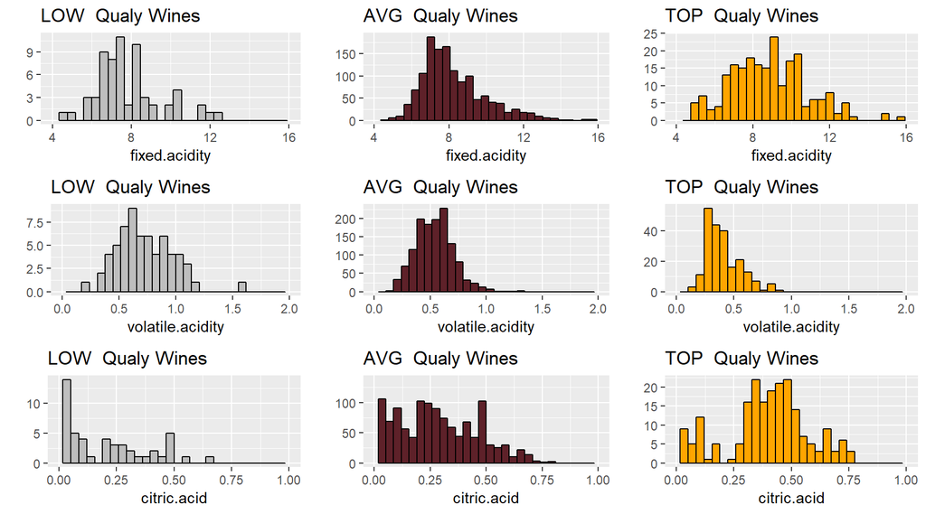

Ácidex Fixa -> Maior concentração maior a qualidade

```
## # A tibble: 3 x 4
##   quality.group  Mean Median DevPad
##   <fct>         <dbl>  <dbl>  <dbl>
## 1 LOW            7.87   7.50   1.65
## 2 AVG            8.25   7.80   1.68
## 3 TOP            8.85   8.70   2.00
```

Ácidez Volatil -> Menor concentração maior a qualidade

```
## # A tibble: 3 x 4
##   quality.group  Mean Median DevPad
##   <fct>         <dbl>  <dbl>  <dbl>
## 1 LOW           0.724  0.680  0.248
## 2 AVG           0.539  0.540  0.168
## 3 TOP           0.406  0.370  0.145
```

Ácido Cítrico -> Maior concentração maior a qualidade

```
## # A tibble: 3 x 4
##   quality.group  Mean Median DevPad
##   <fct>         <dbl>  <dbl>  <dbl>
## 1 LOW           0.174 0.0800  0.207
## 2 AVG           0.258 0.240   0.188
## 3 TOP           0.376 0.400   0.194
```

Acidez Fixa + Volatil -> Vamos somar as duas e ver se elas podem ser usadas em conjunto.

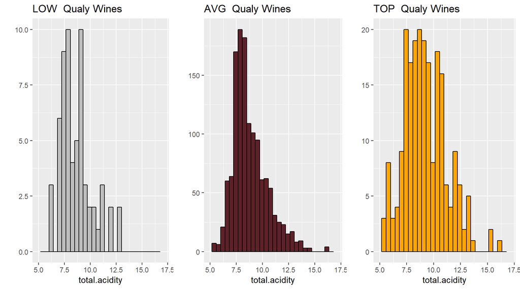

```
## # A tibble: 3 x 4
##   quality.group  Mean Median DevPad
##   <fct>         <dbl>  <dbl>  <dbl>
## 1 LOW            8.60   8.28   1.60
## 2 AVG            8.79   8.39   1.65
## 3 TOP            9.25   9.04   1.97
```

Ajustei os limites dos gráficos pois tinham muitos outliers

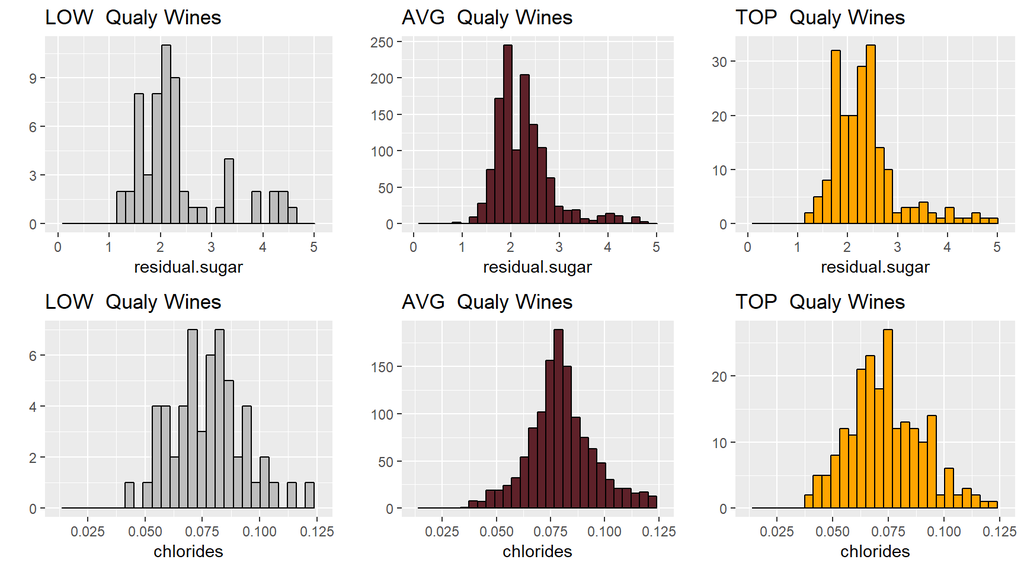

Açucar residaul -> Parece que é uma caracteristica que não é bem definida. Se analisarmos as mulheres e os homens tem gostos diferentes o que pode ter afetado a classificação de qualidade (mulheres tendem a gostar mais de vinhos mais doces, mas é uma especulação). Podemos refazer a analise tirando os outliers.

```
## # A tibble: 3 x 4
##   quality.group  Mean Median DevPad
##   <fct>         <dbl>  <dbl>  <dbl>
## 1 LOW            2.68   2.10   1.72
## 2 AVG            2.50   2.20   1.40
## 3 TOP            2.71   2.30   1.36
```

Clorideos -> Menor concentração caracteristica dos vinhos de melhor qualidade

```
## # A tibble: 3 x 4
##   quality.group   Mean Median DevPad
##   <fct>          <dbl>  <dbl>  <dbl>
## 1 LOW           0.0957 0.0800 0.0751
## 2 AVG           0.0890 0.0800 0.0475
## 3 TOP           0.0759 0.0730 0.0285
```

### 3 - Concentrações de Dioxido de enxofre e sulphatos.

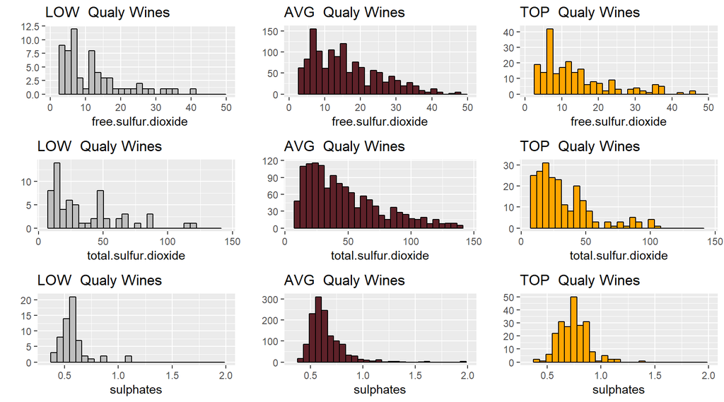

Dioxido de Enxofre Livre (free.sulfur.dioxide) -> Sem muito a nos dizer.

```
## # A tibble: 3 x 4
##   quality.group  Mean Median DevPad
##   <fct>         <dbl>  <dbl>  <dbl>
## 1 LOW            12.1     9.   9.08
## 2 AVG            16.4    14.  10.5
## 3 TOP            14.0    11.  10.2
```

Dioxido de Enxofre Total (free.sulfur.dioxide) -> Sem muito a nos dizer.

```
## # A tibble: 3 x 4
##   quality.group  Mean Median DevPad
##   <fct>         <dbl>  <dbl>  <dbl>
## 1 LOW            34.4    26.   26.4
## 2 AVG            48.9    40.   32.7
## 3 TOP            34.9    27.   32.6
```

Sulfitos (sulphates) -> Já os sulfatos tem muito a nos dizer. Quanto maior a concetração na média melhor qualificado o vinho.

```
## # A tibble: 3 x 4
##   quality.group  Mean Median DevPad
##   <fct>         <dbl>  <dbl>  <dbl>
## 1 LOW           0.592  0.560  0.224
## 2 AVG           0.647  0.610  0.167
## 3 TOP           0.743  0.740  0.134
```

Nesse grupo teve destaque os sulphates, uma maior concetração em vinhos melhores. Em relação ou dioxido de enxofre vemos um outlier nos vinhos melhores, mas olhando o grafico vemos que como os outros grupos não tem tanta relevancia na qualidade.

Dioxido de enxofre fixo -> Vamos subtrair o total do livre.

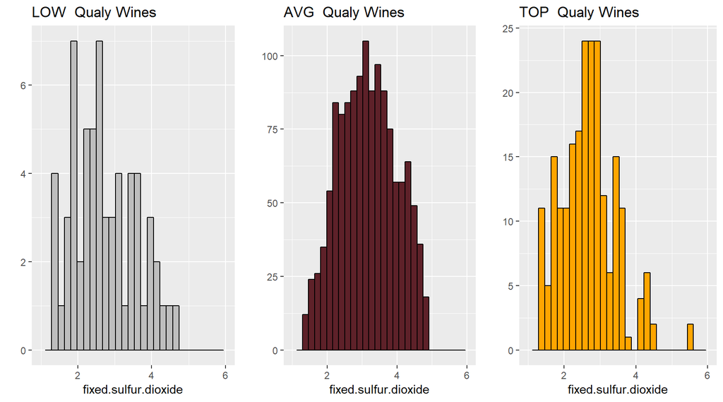

```
##    Min. 1st Qu.  Median    Mean 3rd Qu.    Max.
##   1.099   2.485   3.045   3.081   3.664   5.527
```

```
## [1] 0.8302762
```

### 4- Densidade, pH e nivel de Alcool

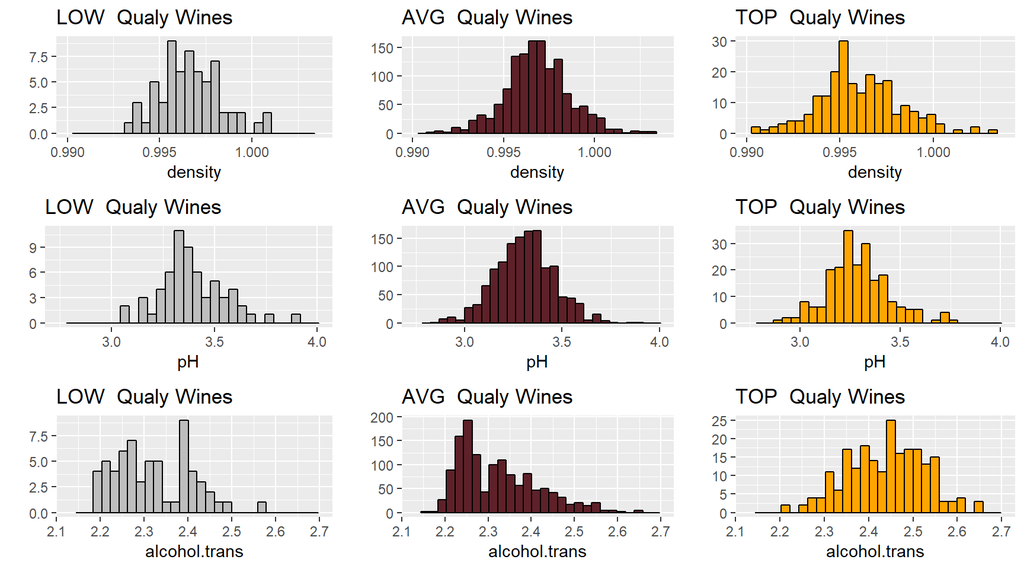

Densidade (density) -> Sem muito a nos dizer a primeira vista.

```
## # A tibble: 3 x 4
##   quality.group  Mean Median  DevPad
##   <fct>         <dbl>  <dbl>   <dbl>
## 1 LOW           0.997  0.997 0.00167
## 2 AVG           0.997  0.997 0.00182
## 3 TOP           0.996  0.996 0.00220
```

Escala pH (pH) -> Vinhos com PH mais baixo, ou seja com maior acidez parecem ser melhores na média.

```
## # A tibble: 3 x 4
##   quality.group  Mean Median DevPad
##   <fct>         <dbl>  <dbl>  <dbl>
## 1 LOW            3.38   3.38  0.175
## 2 AVG            3.31   3.31  0.152
## 3 TOP            3.29   3.27  0.154
```

Nível alcoolico (alcohol) -> Vinhos com nível de alcool maior são melhor classificados.

```
## # A tibble: 3 x 4
##   quality.group  Mean Median DevPad
##   <fct>         <dbl>  <dbl>  <dbl>
## 1 LOW            10.2   10.0  0.918
## 2 AVG            10.3   10.0  0.972
## 3 TOP            11.5   11.6  0.998
```

Podemos pelos gráficos notar que a densidade não parece influenciar muito (de forma direta), que o PH dos melhores vinhos é na media ligeriamente mais acido. Em relação ao nível de alcool os vinhos melhores tem nitidamente uma quantidade maior.

# Análise Univariada

### Qual a estrutura do conjunto de Dados?

Existem 1599 vinhos no nosso *dataset* com um índice (X) e com 11 atributos e um *output* quality. Adcionei um agrupamento por nível de qualidade para poder destacar caracteristicas mais marcantes nos vinho de baixa, media e alta qualidade. A maioria dos vinho, 1319 foram classificados como médios *AVG*, 63 (4%) como de baixa qualidade *LOW* e 217 (13,6%) como de alta qualidade *TOP*. LOW | AVG | TOP —-|——|—- 63 | 1319 | 217

Outras observaçães. - A distribuição da qualidade dos vinhos se aproxima de uma normal com skew positivo. - O pH do vinhos é na média 3,3, os vinho tintos são tem alta acidez. - Nem todos os vinhos possuem ácido cítrico, é a unica propriedade onde tivemos o 0.

### Quais são os principais atributos de interesse deste conjunto de dados?

O meu atributo principal de analise é a qualidade do vinho.

### Quais outros atributos você acha que podem lhe auxiliar na investigação destes atributos de interesse?

Eu elegi o nível de alcool, sulfitos, acidez volatil e fixa e acido citrico.

### Dos atributos investigados, distribuições incomuns foram encontradas? Você aplicou operações nos dados para limpá-los, ajustá-los ou mudar a forma dos dados? Se sim, por quê?

Sim encontrei algumas distribuições fora da normal e com ske positivo, apliquei tranformações com log e raiz quadrada

# Seção de Gráficos Bivariados

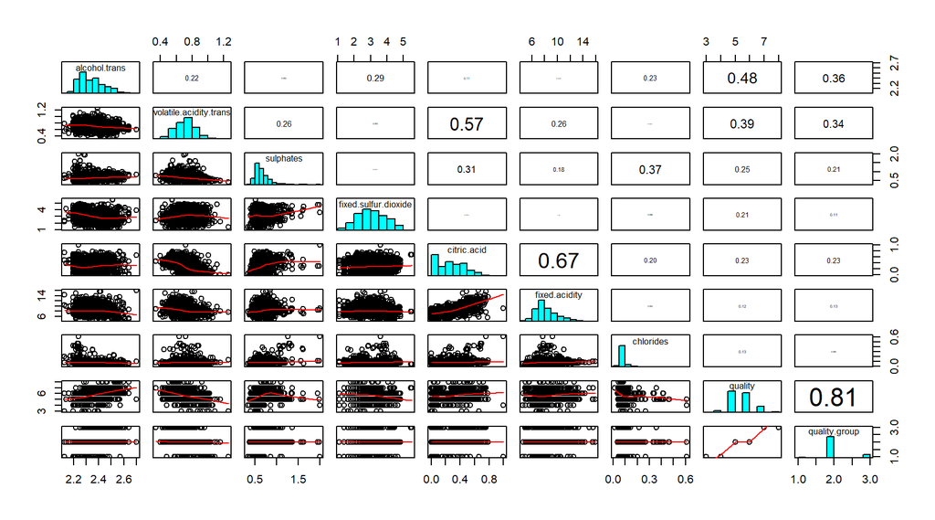

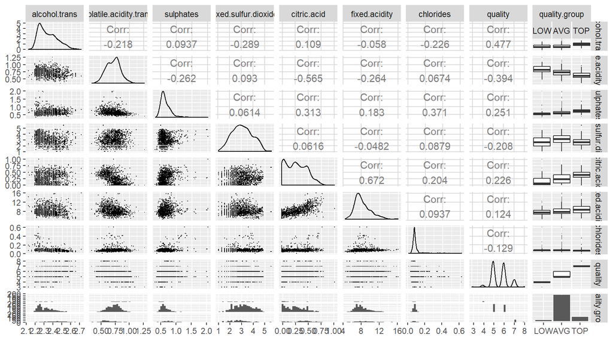

Gráfico Multivariado 1

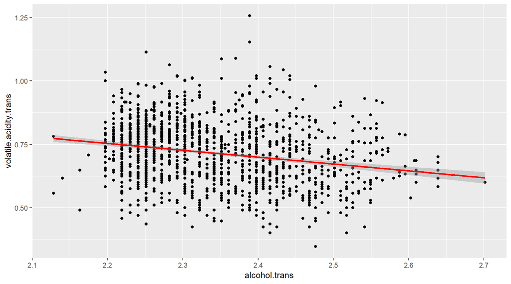

Gráfico Multivariado 2

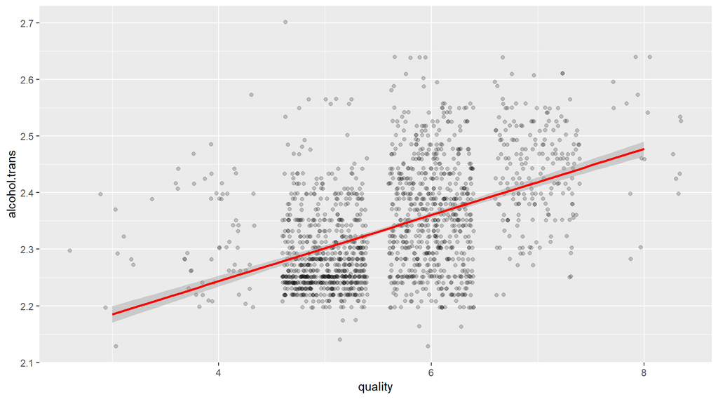

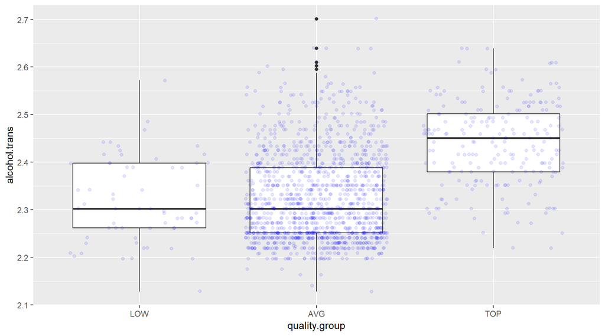

Gráfico Multivariado 3

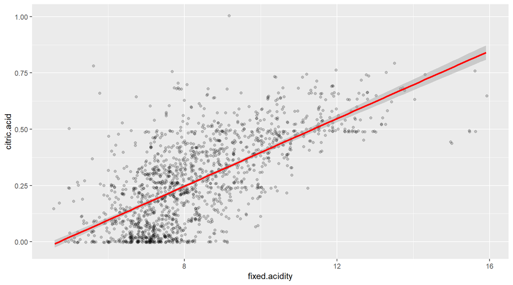

Indica que a acidez do vinho vem em parte do acido citrico. # Análise Bivariada

```
##
##  Pearson's product-moment correlation
##
## data:  df_vinho.sub$fixed.acidity and df_vinho.sub$citric.acid
## t = 36.234, df = 1597, p-value < 2.2e-16
## alternative hypothesis: true correlation is not equal to 0
## 95 percent confidence interval:
##  0.6438839 0.6977493
## sample estimates:
##       cor
## 0.6717034
```

### Discuta sobre alguns dos relacionamentos observados nesta parte da investigação. Como os atributos de interesse variaram no conjunto de dados?

Nenhuma variavel tem uma correlação forte. Encontramos o nivel do alcool proximo a uma correl de 0,5. O que indica que a qualidade do vinho é um somatorio de atributos.

### Você observou algum relacionamento interessante entre os outros atributos (os que não são de interesse)?

Notei que o acido citrico se correlaciona de maneira mais forte com a acidez fixa. São variaveis que não são idenpendentes.

### Qual foi o relacionamento mais forte encontrado?

O relacionamento mais forte encontrado foi entre o acido citrico e a acidez fixa. Depois o nivel de alcool com a qualidade.

# Seção de Gráficos Multivariados

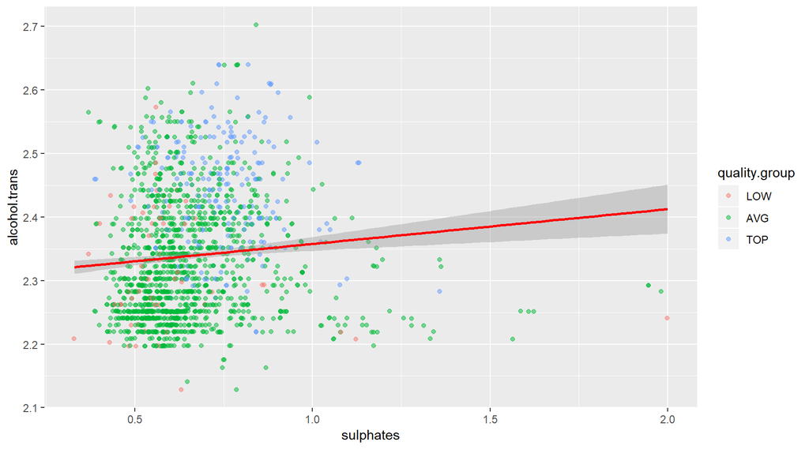

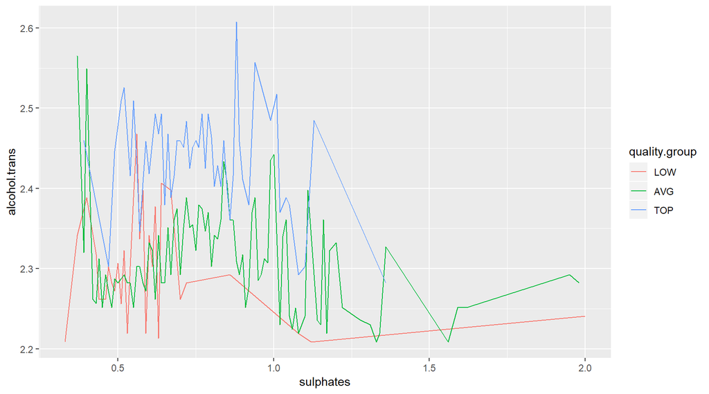

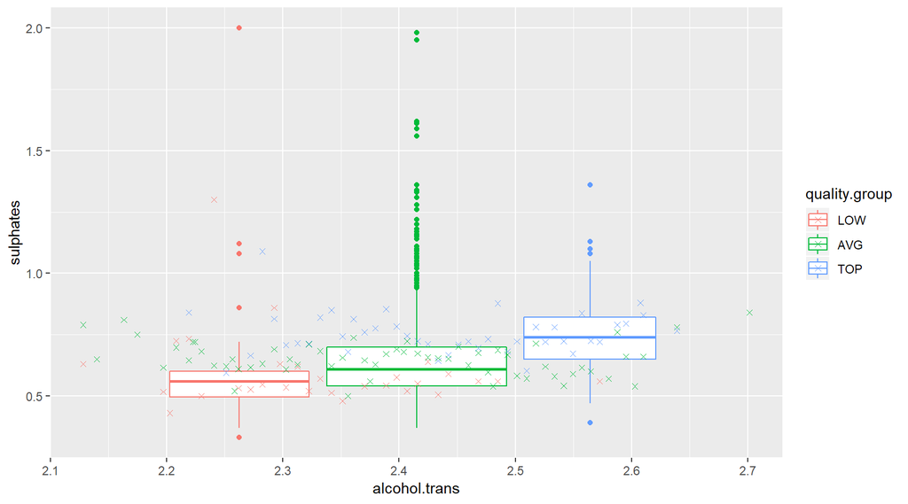